# BCB420 Assignment 1 - Nayeon Hyun

2024-02-13

## Introduction

### Why I Chose This Dataset

For my dataset, I chose the paper, [Human germline biallelic complete NFAT1 deficiency causes the triad of joint contractures, osteochondromas, and susceptibility to B cell malignancy](https://www.ncbi.nlm.nih.gov/geo/query/acc.cgi?acc=GSE193414). I chose a dataset that focuses on B-cell lymphoma as it was related to my BCB430 research. Since my research was on B-cells for B-cell lymphoma, I wanted to look at T-cells and this paper was the perfect dataset to do so. It looks at NFAT1 (nuclear factor of activated T cells 1) which mediates calcium-calcineurin signals that drive cell activation, survival, and proliferation. This paper sequences a human that has a complete deficiency of NAFT1 and analyzes the affect of this deficiency. They also sequence his parents, who have a consanguineous relationship. Sharma et al. (2022)

### Basic Information on the Dataset

There are 18 bulk RNA-seq samples from three patients. One patient is the first reported case of human complete NFAT1 deficiency. The other two are his parents who had a consanguineous relationship. Illumina NextSeq 500 was used for sequencing. Half of the 18 samples (labelled as “patient”) are infected with an empty vector, thus is the negative control. The other 9 samples are infected with WT-NFATC2 which is the test condition.

Each replicate’s patient and rescue samples were treated with PMAIonomycin and IL-1b. Thus there are 3 treatment groups, one untreated, PMAIono, and IL1b for each replicate’s patient and rescue samples.

In the paper, they confirmed the functions of NFAT1 regarding cell-death, where the rescued WT-NFATC2 samples showed significantly less resistance to cell-death compared to the empty vector samples. Sharma et al. (2022)

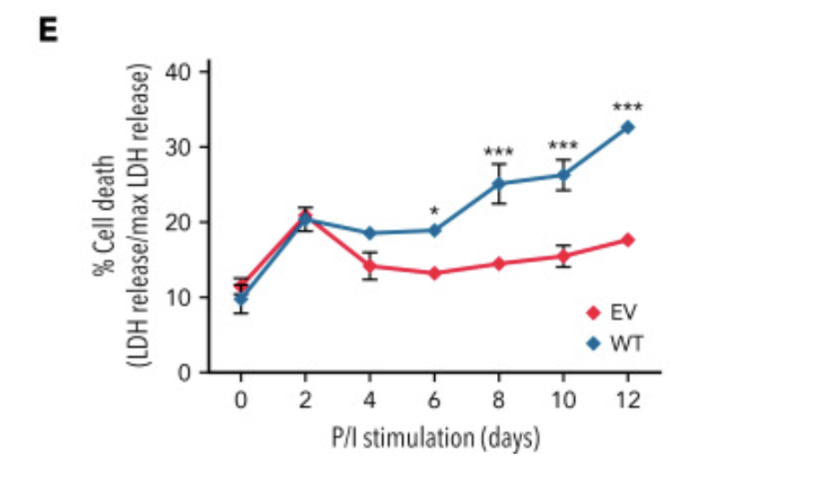

Figure 1: Measurement of percent cell death in chondrocytes. Sharma et al. (2022)

### Downloading Data

The dataset’s GEO accession number is GSE193414. The code below will downloads the raw counts and its metadata into a .rds format. Davis and Meltzer (2007)

```r
# Downloading metadata
accession <- "GSE193414"
if (!file.exists(paste0(accession,".rds"))) {
  metadata <- GEOquery::getGEO(accession, GSEMatrix =TRUE, getGPL=FALSE)
  metadata <- metadata[[1]]
  saveRDS(metadata, paste0(accession, ".rds"))
} else {
  metadata <- readRDS(paste0(accession, ".rds"))
}
```

```r
# Download raw counts
downloadUrl <- "https://www.ncbi.nlm.nih.gov/geo/download/?acc=GSE193414&format=file"
completePath <- paste(downloadUrl, "file=GSE193414_rawcounts.txt.gz", sep="&");
if (!file.exists(paste(accession,"rawCounts.rds", sep = "_"))) {
  countMatrix <- as.matrix(data.table::fread(completePath, header=T, colClasses="integer"), rownames=1)
  saveRDS(countMatrix, paste(accession, "rawCounts.rds", sep = "_"))
} else {
  countMatrix <- readRDS(paste(accession, "rawCounts.rds", sep = "_"))
}
```

## Data Processing

### Process Metadata

The metadata has alot of information but we only need the first column which indicates the sample and its treatment group and the column that indicates the replicate number. With this, we can process the metadata to group each sample with its treatment group. I also added a column that corresponds to the column names in the count matrix to link the two data frames together with its respective sample.

```r
fullMetadata <- metadata@phenoData@data
sampleMetadata <- fullMetadata[1] # extract relevant columns
sampleMetadata$Replicate <- fullMetadata$"replicate number:ch1"

# we need to add a column for the treatment group (ex. Rescue-unstim, Patient-IL1B).
treatmentGroup <- c()
cmSampleName <- c()
for (title in sampleMetadata$title) {
  splitDashes <- unlist(strsplit(title, "-", perl=TRUE))
  treatmentGroup <- c(treatmentGroup, paste(splitDashes[2], splitDashes[3], sep = "-"))
  if (splitDashes[2] == "Patient") {
    cmSampleName <- c(cmSampleName, paste0("P", substring(splitDashes[1], 2, 2), "_", splitDashes[3]))
  } else {
    cmSampleName <- c(cmSampleName, paste0("Res", substring(splitDashes[1], 2, 2), "_", splitDashes[3]))
  }

}
sampleMetadata$Treatment_group <- treatmentGroup
sampleMetadata$CountMatrix_colname <- cmSampleName
head(sampleMetadata)
```

```
##                         title Replicate Treatment_group CountMatrix_colname
## GSM5799904   N2-Rescue-unstim         2   Rescue-unstim         Res2_unstim
## GSM5799905     N2-Rescue-IL1B         2     Rescue-IL1B           Res2_IL1B
## GSM5799906  N2-Rescue-PMAIono         2  Rescue-PMAIono        Res2_PMAIono
## GSM5799907  N3-Patient-unstim         3  Patient-unstim           P3_unstim
## GSM5799908    N3-Patient-IL1B         3    Patient-IL1B             P3_IL1B
## GSM5799909 N3-Patient-PMAIono         3 Patient-PMAIono          P3_PMAIono
```

### Initial Data Preparation

Looking at the raw counts, the genes seem to be in a HUGO format.

```r
# Read raw counts
countMatrix <- readRDS(paste(accession, "rawCounts.rds", sep = "_"))
rownames(countMatrix)[1:10]
```

```
##  [1] "DDX11L1"    "WASH7P"     "MIR6859-3"  "MIR6859-2"  "MIR6859-4"
##  [6] "MIR6859-1"  "MIR1302-11" "MIR1302-9"  "MIR1302-2"  "MIR1302-10"
```

We first check that the count matrix has no `NA` values.

```r
any(is.na(countMatrix))
```

```
## [1] TRUE
```

```r
countMatrix <- na.omit(countMatrix) # first line returned TRUE so we need to remove
any(is.na(countMatrix)) #yay!
```

```
## [1] FALSE
```

We now check that the count matrix has no negative values.

```r
any(countMatrix < 0) # no negative values so no need to filter.
```

```
## [1] FALSE
```

Lastly, we will check if the count matrix has any duplicate gene counts.

```r
length(unique(rownames(countMatrix))) == length(rownames(countMatrix)) # no duplicate gene counts.
```

```
## [1] TRUE
```

### Filtering Out Genes with Low Expression Counts

Rows may have expression counts of 0 in all samples, and these can be filtered out to avoid heavy computation. This dataset there are 3 control samples so we will filter out those where at least 3 samples have expression counts greater than 1cpm (counts per million). Robinson, McCarthy, and Smyth (2010)

```r
atleast3 <- rowSums( edgeR::cpm(countMatrix) > 1 ) >= 3
filteredCM <- countMatrix[atleast3, ]
dim(countMatrix)
```

```
## [1] 26364    18
```

```r
dim(filteredCM) # more than half of the genes are filtered out
```

```
## [1] 12925    18
```

### Initial Analysis

Now, we look at the expression levels of NFATC2, the gene which encodes the NFAT1 transcription factor. The patient carried a homozygous 4–base-pair deletion of the gene NFATC2. This variant causes a frame shift leading to a premature stop codon, which significantly reduced NFATC2 transcript abundance and resulted in an undetectable NFAT1 expression. We can see that the samples with the WT-NFATC2 (prefix with “Res”) treatment has significantly higher NFATC2 expression than the patient samples. Sharma et al. (2022)

```r
# Read raw counts
NFAT1Counts <- countMatrix["NFATC2",]
NFAT1Counts
```

```
##    P1_unstim    P2_unstim    P3_unstim      P1_IL1B      P2_IL1B      P3_IL1B
##           62          101           50           62           94           43
##   P1_PMAIono   P2_PMAIono   P3_PMAIono  Res1_unstim  Res2_unstim  Res3_unstim
##           75           32           57        17045         9845        14579
##    Res1_IL1B    Res2_IL1B    Res3_IL1B Res1_PMAIono Res2_PMAIono Res3_PMAIono
##        25646        15921        21739        49432        30080        44380
```

### TMM Normalisation

TMM is applied to normalise the raw count matrix. Robinson, McCarthy, and Smyth (2010)

```r
dgeList = edgeR::DGEList(counts=filteredCM, group=sampleMetadata$Treatment_group)
dgeList = edgeR::calcNormFactors(dgeList)
normalisedCountMatrix <- edgeR::cpm(dgeList)
normalisedCountMatrix["NFATC2",]
```

```
##    P1_unstim    P2_unstim    P3_unstim      P1_IL1B      P2_IL1B      P3_IL1B
##     2.500447     3.785921     2.083323     2.721467     4.233360     1.834994
##   P1_PMAIono   P2_PMAIono   P3_PMAIono  Res1_unstim  Res2_unstim  Res3_unstim
##     3.212403     1.233255     2.289916   652.188058   406.507914   542.511859
##    Res1_IL1B    Res2_IL1B    Res3_IL1B Res1_PMAIono Res2_PMAIono Res3_PMAIono
##  1075.426338   721.707798   918.989839  1985.124806  1275.361046  1761.654590
```

We now analyze the sample separation using a MDS plot post normalization to determine the distance between samples. Ritchie et al. (2015)

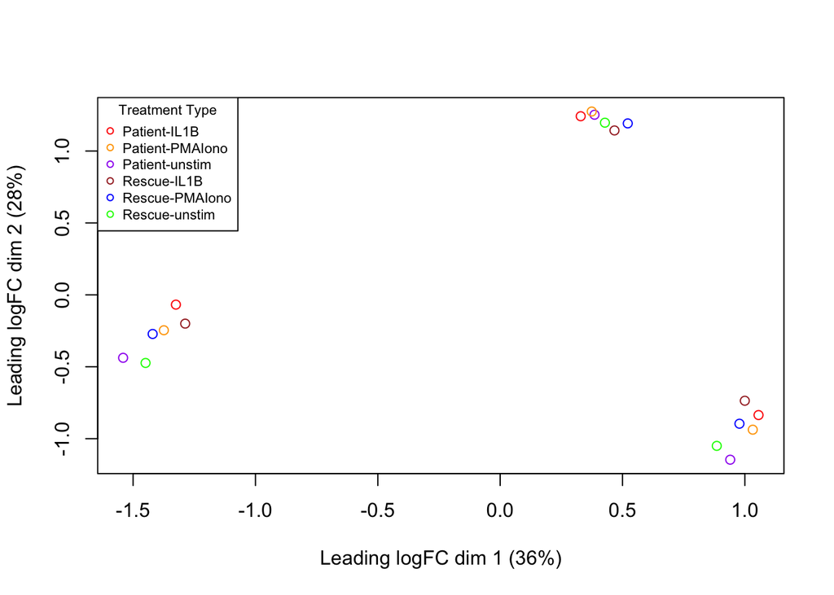

```r
# Plot by treatment group
limma::plotMDS(dgeList, labels=NULL,pch=1,
               col = c("red","orange","purple","brown", "blue", "green")[factor(sampleMetadata$Treatment_group)])
par(cex = 0.7) # change legend font size
legend("topleft", legend = levels(factor(sampleMetadata$Treatment_group)),
       col = c("red","orange","purple","brown", "blue", "green"), pch = 1, title = "Treatment Type", )
```

Now, when plotted by each replicate, we can identify which of the dots in the prior plot belongs to which replicate. This allows us to see the significant separation between the Patient empty vector samples and the Rescued WT-NFACT2 samples from the same replicate. Ritchie et al. (2015)

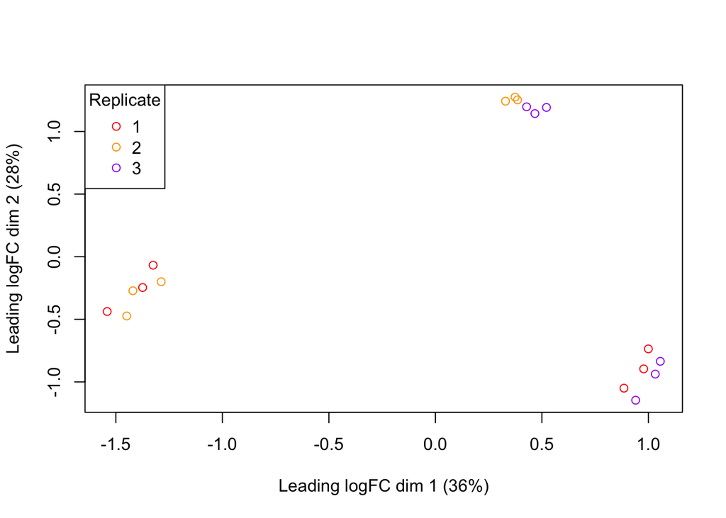

```r
# Plot by replicate
limma::plotMDS(dgeList, labels=NULL,pch=1,
               col = c("red","orange","purple")[factor(sampleMetadata$Replicate)])
par(cex = 1) # change legend font size
legend("topleft", legend = levels(factor(sampleMetadata$Replicate)),
       col = c("red","orange","purple"), pch = 1, title = "Replicate", )
```

## References

Davis, Sean, and Paul S Meltzer. 2007. “GEOquery: A Bridge Between the Gene Expression Omnibus (GEO) and BioConductor.” *Bioinformatics* 23 (14): 1846–47.

Ritchie, Matthew E, Belinda Phipson, DI Wu, Yifang Hu, Charity W Law, Wei Shi, and Gordon K Smyth. 2015. “Limma Powers Differential Expression Analyses for RNA-Sequencing and Microarray Studies.” *Nucleic Acids Research* 43 (7): e47–47.

Robinson, Mark D, Davis J McCarthy, and Gordon K Smyth. 2010. “edgeR: A Bioconductor Package for Differential Expression Analysis of Digital Gene Expression Data.” *Bioinformatics* 26 (1): 139–40.

Sharma, Mehul, Maggie P Fu, Henry Y Lu, Ashish A Sharma, Bhavi P Modi, Christina Michalski, Susan Lin, et al. 2022. “Human Complete NFAT1 Deficiency Causes a Triad of Joint Contractures, Osteochondromas, and b-Cell Malignancy.” *Blood, The Journal of the American Society of Hematology* 140 (17): 1858–74.